# Problem Statement

## We want to investigate what are the requirements for interaction designer in San Francisco and New York by looking at data scraped from indeed.com. We find the common skills required in these two markets.

# 1. San Francisco

## Using scrapy, we engineer the code to get the summary and title of the postings from indeed.com. We use XPatch Checker plugin in Chrome to find the xpath of the elements in the web page for the summary field and title field.

## Here's the code for the XPaths used

[figure not shown]

## Here's the code for the urls used

[figure not shown]

## We then used the code to obtain the data below.

```python
# This is for UX/UI Interaction Designers - SF
indeed_sf_data = pd.read_csv('indeed_ux_sf.csv')
```

```python
indeed_sf_df.head(3)
```

|  | title | summary |
| --- | --- | --- |
| 0 | User Experience Researcher, Uber Freight | Our research will make the process of moving r... |
| 1 | Interaction Designer | \nWe follow a simple but vital premise on UX t... |
| 2 | Design | \nExperience collaborating with UX Designers/R... |

## We will use CountVectorizer from the sklearn package to analyze the data.

```python
from sklearn.feature_extraction.text import CountVectorizer
cvec1 = CountVectorizer()
cvec1.fit(indeed_sf_df['summary'])
```

```
CountVectorizer(analyzer=u'word', binary=False, decode_error=u'strict',
        dtype=<type 'numpy.int64'>, encoding=u'utf-8', input=u'content',
        lowercase=True, max_df=1.0, max_features=None, min_df=1,
        ngram_range=(1, 1), preprocessor=None, stop_words=None,
        strip_accents=None, token_pattern=u'(?u)\\b\\w\\w+\\b',
        tokenizer=None, vocabulary=None)
```

## The raw data looks like this:

```python
df1.transpose().sort_values(0, ascending=False).head(10).transpose().head(3)
```

|  | 44 | 764 | 775 | 915 | 1014 | 501 | 615 | 635 | 971 | 209 |
| --- | --- | --- | --- | --- | --- | --- | --- | --- | --- | --- |
| 0 | 3 | 2 | 2 | 2 | 1 | 1 | 1 | 1 | 1 | 1 |
| 1 | 2 | 0 | 0 | 1 | 0 | 0 | 0 | 0 | 2 | 0 |
| 2 | 3 | 0 | 0 | 0 | 0 | 0 | 0 | 0 | 1 | 0 |

```python
X_train, X_test, y_train, y_test = train_test_split(X, y, test_size=0.4)
```

## We will run Logistic Regression on this set.

```python
logreg = LogisticRegression()
```

```python
logreg.fit(X_train, y_train)
```

```
LogisticRegression(C=1.0, class_weight=None, dual=False, fit_intercept=True,
          intercept_scaling=1, max_iter=100, multi_class='ovr', n_jobs=1,
          penalty='l2', random_state=None, solver='liblinear', tol=0.0001,
          verbose=0, warm_start=False)
```

## Now that we trained on the subset, we can now run prediction on the test subset.

```python
df_predict = logreg.predict(X_test)
```

## Here is our score on this set

```python
df_score = logreg.score(X_test, y_test)
```

```python
df_score
```

```
0.6741573033707865
```

## Now we run the analysis more discrimination, splitting data more carefully

```python
# set ngram_range up to 3, to catch phrases like 'nat lang proc'
cvec2 = CountVectorizer(stop_words = 'english', ngram_range=(1,3))
```

```python
indeed_sf_df['title']= indeed_sf_df['title'].map(lambda x: x.strip())
```

```python
indeed_sf_df['summary'] = indeed_sf_df['summary'].map(lambda x: x.strip())
```

```python
indeed_sf_df['ux_ui_designer'] = indeed_sf_df['title'].map(lambda x: 1 if 'UX/UI designer'
                                in x.lower() else 0)
```

```python
indeed_sf_df['interaction_designer'] = indeed_sf_df['title'].map(lambda x: 1 if
                            'interaction designer' in x.lower() else 0)
```

## We run new traing and testing on the new data.

```python
X_train2, X_test2, y_train2, y_test2 = train_test_split(X2, y2, test_size=0.4)
```

## We have a new Logistic Regression training

```python
logreg2 = LogisticRegression()
```

```python
logreg2.fit(X_train2, y_train2)
```

```
LogisticRegression(C=1.0, class_weight=None, dual=False, fit_intercept=True,
          intercept_scaling=1, max_iter=100, multi_class='ovr', n_jobs=1,
          penalty='l2', random_state=None, solver='liblinear', tol=0.0001,
          verbose=0, warm_start=False)
```

## The new predictions and score is better now:

```python
df_predict2 = logreg2.predict(X_test2)
```

```python
logreg2.score(X_test2, y_test2)
```

```
0.97752808988764039
```

## Here are some of the columns we get

```python
X3.columns
```

```
Index([u'10', u'10 engineers', u'10 engineers 100', u'100', u'100 people',
       u'100 people location', u'107', u'12', u'12 months', u'12 months job',
       ...
       u'years ux ui', u'years work', u'years work experience', u'yelp',
       u'yelp conquer', u'yelp conquer challenging', u'york', u'zendesk',
       u'zendesk looking', u'zendesk looking product'],
      dtype='object', length=5229)
```

## We create a dictionary of these skills we found:

```python
interaction_designer_dic = {
                    'research':0,
                    'uber':0,
                    'yelp':0,
                    'years ux ui':0,
                    'process moving':0,
                    'research team':0,
                    'ux research':0,
                    'product designer':0,
                    'process looking':0,
                    'profile':0
}

for c in X3.columns:
    for key in interaction_designer_dic:
        if key in c.lower():
            interaction_designer_dic[key] += 1

print interaction_designer_dic
```

```
{'uber': 6, 'profile': 8, 'product designer': 36, 'yelp': 6, 'research team': 2, 'ux research': 20, 'years ux ui': 1, 'process looking': 4, 'process moving': 3, 'research': 102}
```

## Here is what they look like:

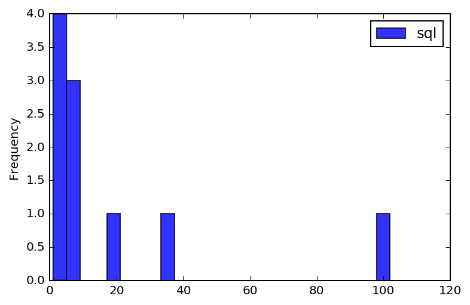

```python
ax = pd.DataFrame({'sql': interaction_designer_dic}).plot(kind='hist', bins=25, alpha=0.8)
plt.show()
```

## Or in matplot, they look like this:

```
array([[<matplotlib.axes._subplots.AxesSubplot object at 0x11e8c9d10>]], dtype=object)
```

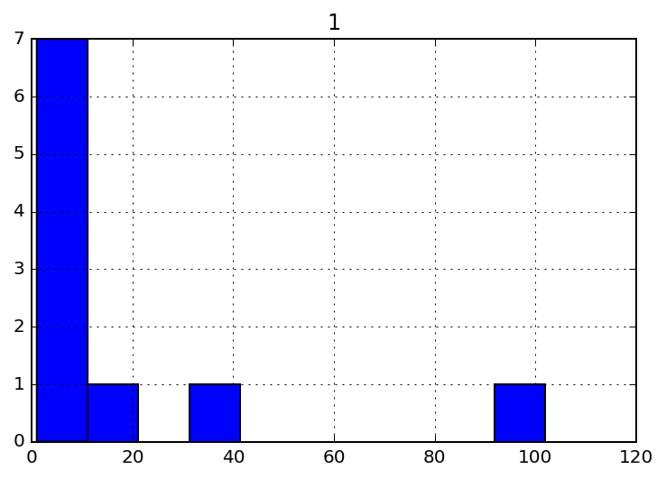

```python
interaction_designer_df.hist()
```

## 2. New York

## We look now at the New York data.

```python
# This is for UX/UI Interaction Designers - NY
indeed_ny_data = pd.read_csv('indeed_ux_ny.csv')
```

```python
indeed_ny_df = pd.DataFrame(indeed_ny_data)
```

```python
indeed_ny_df.head(3)
```

|  | title | summary |
| --- | --- | --- |
| 0 | Service Experience Designer | Service Experience Designer*. As a Service Exp... |
| 1 | User Experience Designer - Data Distribution a... | \nThis position is for a thoughtful UX Designe... |
| 2 | UX Designer | \nCollaborate with an Interaction Designer to ... |

## We use CountVectorizer to look at 'summary' and then fit that data.

```python
cvec3 = CountVectorizer()
cvec3.fit(indeed_ny_df['summary'])
```

```
CountVectorizer(analyzer=u'word', binary=False, decode_error=u'strict',
        dtype=<type 'numpy.int64'>, encoding=u'utf-8', input=u'content',
        lowercase=True, max_df=1.0, max_features=None, min_df=1,
        ngram_range=(1, 1), preprocessor=None, stop_words=None,
        strip_accents=None, token_pattern=u'(?u)\\b\\w\\w+\\b',
        tokenizer=None, vocabulary=None)
```

## We pre-process before running train and test on the data.

df3 = pd.DataFrame(cvec3.transform(indeed_ny_df['summary']).todense())

```python
df3.transpose().sort_values(0, ascending=False).head(10).transpose().head(3)
```

|  | 852 | 361 | 253 | 643 | 59 | 970 | 113 | 757 | 1052 | 984 |
| --- | --- | --- | --- | --- | --- | --- | --- | --- | --- | --- |
| 0 | 3 | 3 | 3 | 1 | 1 | 1 | 1 | 1 | 1 | 1 |
| 1 | 0 | 0 | 1 | 0 | 0 | 0 | 0 | 0 | 0 | 0 |
| 2 | 0 | 0 | 1 | 0 | 1 | 2 | 0 | 0 | 0 | 0 |

```python
XX = cvec3.fit_transform(indeed_ny_df['summary'])
```

```python
yy = indeed_ny_df['title'].values
```